# location experiment

R. A. Reitmeyer

2017-05-19

# Let’s look at locations

Can we get X and Y coordinates for the metro stations and train stations, up to rotation about the city center?

## Simulate data

```r
set.seed(20170519) # for repeatability

num_house <- 100
num_metro <- 15
num_train <- 10

houses <- data.frame(house_id=1:num_house, actual_x=10*rnorm(num_house), actual_y=10*rnorm(num_house))
city_center <- data.frame(id=0, actual_x=0, actual_y=0)
metro_stations <- data.frame(metro_id=1:num_metro, actual_x=10*rnorm(num_metro), actual_y=10*rnorm(num_metro))
train_stations <- data.frame(train_id=1:num_train, actual_x=10*rnorm(num_train), actual_y=10*rnorm(num_train))

find_rt <- function(thing=NULL, house=NULL, thing_name='house', col_prefix='actual')
{
    col_x <- paste(col_prefix, 'x', sep='_')
    col_y <- paste(col_prefix, 'x', sep='_')
    col_r <- paste(col_prefix, 'r', sep='_')
    col_t <- paste(col_prefix, 't', sep='_')
    if (!is.null(thing)) {
        retval <- data.frame(
            r=sqrt(thing[,col_x]^2+thing[,col_y]^2),
            t=atan2(thing[,col_y],thing[,col_x])
        )
    } else if (!is.null(house) && thing_name %in% c('metro', 'train')) {
        num_thing <- ifelse(thing_name == 'metro', num_metro, num_train)
        id_col <- paste(thing_name, 'id', sep='_')
        km_col <- paste(thing_name, 'km', sep='_')
        no_thing <- setdiff(1:num_thing, unique(house[,id_col]))

        thing_r <- sapply(1:num_thing, function(i) {
            mean(house[house[,id_col]==i,'center_km'])
        })
        thing_r[no_thing] <- mean(house$center_km)
        retval <- data.frame(r=thing_r, t=NA)
    }
    return(retval)
}

# just for sanity checking
simple_dist <- function(r1, r2, c1='actual', c2='actual') {
    return (sqrt((r2[,make_name(c2, 'x')]-r1[,make_name(c1, 'x')])^2+
                     (r2[,make_name(c2, 'y')]-r1[,make_name(c1, 'y')])^2))
}

# en masse computation of closest o2 to each o1, with o2 id and distance.
id_dist <- function(o1, o2, c1='actual', c2='actual', o2_name='X')
{
    l1 <- nrow(o1)
    l2 <- nrow(o2)
    x1 <- matrix(o1[,make_name(c1, 'x')], nrow=l1, ncol=l2)
    x2 <- t(matrix(o2[,make_name(c2, 'x')], nrow=l2, ncol=l1))
    y1 <- matrix(o1[,make_name(c1, 'y')], nrow=l1, ncol=l2)
    y2 <- t(matrix(o2[,make_name(c2, 'y')], nrow=l2, ncol=l1))
    d <- sqrt((x2-x1)^2+(y2-y1)^2)
    id <- apply(d, 1, which.min)
    retval <- data.frame(id=apply(d, 1, which.min), d=apply(d, 1, min))
    names(retval) <- paste(o2_name, c('id', 'km'), sep='_')
    return (retval)
}

house_dist <- function(house, o2, c1='actual', c2='actual', o2_name='X')
{
    o1x <- house[,make_name(c1, 'x')]
    o1y <- house[,make_name(c1, 'y')]
    o2x <- o2[house[,make_name(o2_name, 'id')], make_name(c2, 'x')]
    o2y <- o2[house[,make_name(o2_name, 'id')], make_name(c2, 'y')]
    dx2 <- (o1x-o2x)^2
    dy2 <- (o1y-o2y)^2
    return (sqrt(dx2 + dy2))
}


# update houses with distances
houses <- cbind(houses,
                id_dist(houses, city_center, o2_name='center'),
                id_dist(houses, metro_stations, o2_name='metro'),
                id_dist(houses, train_stations, o2_name='train'))
```

## Define solution vector.

Our solution vector will be the (X,Y) pair for each house, followed by the (X,Y) pair for each metro station, followed by the (X,Y) pair for each train station. So every X will have an odd index 1… and every Y will have an even index 2…

```r
wrong_thing_penalty_factor <- 10

sv_to_objs <- function(sv)
{
    offset <- 0
    e_house <- data.frame(house_id=1:num_house, est_x=sv[offset+seq(1,2*num_house,2)], est_y=sv[offset+seq(2,2*num_house,2)])
    e_house <- cbind(e_house, houses[,c('center_id', 'center_km', 'metro_id', 'metro_km', 'train_id', 'train_km')])
    offset <- 2*num_house
    e_metro <- data.frame(metro_id=1:num_metro, est_x=sv[offset+seq(1,2*num_metro,2)], est_y=sv[offset+seq(2,2*num_metro,2)])
    offset <- 2*num_house+2*num_metro
    e_train <- data.frame(train_id=1:num_train, est_x=sv[offset+seq(1,2*num_train,2)], est_y=sv[offset+seq(2,2*num_train,2)])
    return (list(e_house=e_house, e_metro=e_metro, e_train=e_train))
}

wrong_thing_closest_penalty_score <- function(house, o2, c1='actual', c2='actual', o2_name='metro')
{
    thing_id <- make_name(o2_name, 'id')
    thing_km <- make_name(o2_name, 'km')
    thing_id_dist <- id_dist(house, o2, c1='est', c2='est', o2_name=o2_name)
    thing_id_idx <- which(house[,thing_id] != thing_id_dist[,thing_id])
    thing_id_penalty <- 0
    if (length(thing_id_idx) != 0) {
        thing_id_penalty <- sum(((house[,thing_km]-thing_id_dist[,thing_km])^2)[thing_id_idx])
    }
    return (thing_id_penalty)
}

sv_score <- function(sv)
{
    stopifnot(all(!is.nan(sv)))
    stopifnot(all(!is.na(sv)))

    objs <- sv_to_objs(sv)
    center_d <- house_dist(objs$e_house, city_center, c1='est', o2_name='center')
    center_d_error <- center_d - objs$e_house[,'center_km']
    metro_d <- house_dist(objs$e_house, objs$e_metro, c1='est', c2='est', o2_name='metro')
    metro_d_error <- metro_d - objs$e_house[,'metro_km']
    train_d <- house_dist(objs$e_house, objs$e_train, c1='est', c2='est', o2_name='train')
    train_d_error <- train_d - objs$e_house[,'train_km']

    score <- sum(center_d_error^2)+sum(metro_d_error^2)+sum(train_d_error^2)

    # Now look for 'wrong thing is closer than actual thing.'
    metro_id_penalty <- wrong_thing_closest_penalty_score(objs$e_house, objs$e_metro, c1='est', c2='est', o2_name='metro')

    train_id_penalty <- wrong_thing_closest_penalty_score(objs$e_house, objs$e_train, c1='est', c2='est', o2_name='train')

    score <- score + wrong_thing_penalty_factor*(metro_id_penalty + train_id_penalty)
    #print(sprintf('score is %f', score))
    return(score/length(sv)*100)
}

sv_partials <- function(sv, pseudo_gain=1)
{
    objs <- sv_to_objs(sv)
    p_center <- house_partials(objs$e_house, city_center, c1='est', o2_name='center', pseudo_gain=pseudo_gain)
    p_metro  <- house_partials(objs$e_house, objs$e_metro, c1='est', c2='est', o2_name='metro', pseudo_gain=pseudo_gain)
    p_train  <- house_partials(objs$e_house, objs$e_train, c1='est', c2='est', o2_name='train', pseudo_gain=pseudo_gain)
    return ((p_center+p_metro+p_train)/length(sv)*100)

}

house_partials <- function(house, o2, c1='actual', c2='actual', o2_name='X', pseudo_gain=1)
{
    o2_id <- house[,make_name(o2_name, 'id')]
    o1x <- house[,make_name(c1, 'x')]
    o1y <- house[,make_name(c1, 'y')]
    o2x <- o2[o2_id, make_name(c2, 'x')]
    o2y <- o2[o2_id, make_name(c2, 'y')]
    D <- house[,make_name(o2_name, 'km')]

    hp <- house_partials_internals(o1x, o1y, o2x, o2y, o2_name, o2_id, D, ignore_overage=FALSE, pseudo_gain=pseudo_gain)
    htp <- 0
    if (o2_name %in% c('metro', 'train')) {
        thing_id_dist <- id_dist(house, o2, c1='est', c2='est', o2_name=o2_name)
        t2_id <- thing_id_dist[,make_name(o2_name, 'id')]
        t2x <- o2[t2_id, make_name(c2, 'x')]
        t2y <- o2[t2_id, make_name(c2, 'y')]
        tD <- apply(matrix(c(D, thing_id_dist[,make_name(o2_name, 'km')]), ncol=2), 1, max)
        htp <- house_partials_internals(o1x, o1y, t2x, t2y, o2_name, t2_id, tD, ignore_overage=TRUE, pseudo_gain=pseudo_gain)
    }
    return (hp+wrong_thing_penalty_factor*htp)
}

# Compute the partial for o1x, o1y, o2x and o2y where correct distance is D.
# To facilitate cases where D is a minium distance, you can specify
# ignore_overage and any d > D won't count.
house_partials_internals <- function(o1x, o1y, o2x, o2y, o2_name, o2_id, D, ignore_overage=FALSE, pseudo_gain=1)
{
    num_thing <- 1
    if (o2_name == 'metro') {
        num_thing <- num_metro
    } else if (o2_name == 'train') {
        num_thing <- num_train
    }
    #print(sprintf('summary of o1x, o1y, o2x, o2y when processing %s', o2_name))
    #print(xtabs(~o2_id))
    #print(summary(o1x))
    #print(summary(o1y))
    #print(summary(o2x))
    #print(summary(o2y))
    stopifnot(length(o1x) == length(o1y))
    stopifnot(length(o1x) == length(o2x))
    stopifnot(length(o1x) == length(o2y))
    stopifnot(length(o1x) == length(o2_id))
    stopifnot(length(o1x) == length(D))

    # per maxima:
    # diff((sqrt((x2-x1)^2+(y2-y1)^2)-D)^2,x1)
    #                                            2            2
    #                 2 (x2 - x1) (sqrt((y2 - y1)  + (x2 - x1) ) - D)
    #         - -----------------------------------------------
    #                                        2            2
    #                          sqrt((y2 - y1)  + (x2 - x1) )
    # diff((sqrt((x2-x1)^2+(y2-y1)^2)-D)^2,x2);
    #                                           2            2
    #                2 (x2 - x1) (sqrt((y2 - y1)  + (x2 - x1) ) - D)
    #          -----------------------------------------------
    #                                       2            2
    #                         sqrt((y2 - y1)  + (x2 - x1) )
    d <- sqrt((o2x-o1x)^2 + (o2y-o1y)^2)

    stopifnot(all(!is.nan(d)))
    stopifnot(all(!is.na(d)))

    # have one record per house so d/dx and d/dy for o1 x and y is straightforward.
    # add a pseudo-gain to the denominator to avoid divide-by-zero blowup on
    # very small distances.
    do1x <- -1*(o2x-o1x)*(d-D)/(d+1/pseudo_gain)
    do1y <- -1*(o2y-o1y)*(d-D)/(d+1/pseudo_gain)

    # If we're handling a minimum constraint, ignore distances over the
    # specified minimum.
    if (ignore_overage) {
        idx <- (d>D)
        if (any(idx) > 0) {
            do1x[idx] <- 0
            do1y[idx] <- 0
        }
    }

    stopifnot(all(!is.nan(do1x)))
    stopifnot(all(!is.na(do1x)))
    stopifnot(all(!is.nan(do1y)))
    stopifnot(all(!is.na(do1y)))

    # d/x2 is -1*d/dx1, so invert sign to get d/dx2.
    # Each x and y for o2 is used several times, so have to sum all contributions.
    do2x <- sapply(1:num_thing, function(i) { sum(-1*do1x[o2_id == i]) })
    do2y <- sapply(1:num_thing, function(i) { sum(-1*do1y[o2_id == i]) })
    stopifnot(length(do2x) == length(1:num_thing))
    stopifnot(length(do2y) == length(1:num_thing))

    # form new vector with house x,y interleaved, then metro x,y interleaved,
    # then train x,y interleaved. Note this means we don't return jacobian
    # elements for center... we know where that is.
    mj_house <- matrix(c(do1x, do1y), nrow=num_house, ncol=2)
    if (o2_name == 'metro') {
        stopifnot(length(do2x) == num_metro)
        mj_metro <- matrix(c(do2x, do2y), nrow=num_metro, ncol=2)
    } else {
        mj_metro <- matrix(0, nrow=num_metro, ncol=2)
    }
    if (o2_name == 'train') {
        stopifnot(length(do2x) == num_train)
        mj_train <- matrix(c(do2x, do2y), nrow=num_train, ncol=2)
    } else {
        mj_train <- matrix(0, nrow=num_train, ncol=2)
    }
    #print(sprintf('summary of mj_house, mj_metro, mj_train when processing %s', o2_name))
    #print(summary(mj_house))
    #print(summary(mj_metro))
    #print(summary(mj_train))
    mj <- rbind(mj_house, mj_metro, mj_train)

    stopifnot(all(!is.nan(mj)))
    stopifnot(all(!is.na(mj)))

    return (as.vector(t(mj)))
}

initial_estimates <- function(houses, nloop=1, seed=NULL)
{
    num_house <- nrow(houses)
    house_r <- houses[,'center_km']

    # be prepared to handle 'missing' stations
    no_metro <- setdiff(1:num_metro, unique(houses$metro_id))
    no_train <- setdiff(1:num_train, unique(houses$train_id))

    metro_r <- sapply(1:num_metro, function(i) {
        mean(houses[houses$metro_id==i,'center_km'])
        })
    metro_r[no_metro] <- mean(houses$center_km)
    train_r <- sapply(1:num_train, function(i) {
        mean(houses[houses$train_id==i,'center_km'])
        })
    train_r[no_train] <- mean(houses$center_km)

    # arbitrarily assign metro thetas, with some randomization
    if (!is.null(seed)) {
        set.seed(seed)
    }
    metro_theta <- 2*pi/num_metro*sample(1:num_metro)
    stopifnot(all(!is.nan(metro_theta)))

    # loop a few times on trying to move metros to be by trains
    # and vice-versa
    for (j in 1:nloop) {
        # try to (re)locate trains near metros
        train_theta <- sapply(1:num_train, function(i) {
            mean(metro_theta[houses$metro_id[houses$train_id==i]])
        })

        train_theta[no_train] <- pi*(1+runif(1))
        #print(train_theta)
        stopifnot(all(!is.nan(train_theta)))
        # try to relocate metros to be closer to trains.
        metro_theta <- sapply(1:num_metro, function(i) {
            mean(train_theta[houses$train_id[houses$metro_id==i]])
        })
        metro_theta[no_metro] <- pi*(1+runif(1))
        #print(metro_theta)
        stopifnot(all(!is.nan(metro_theta)))
        ## error metric
        #train_theta_error <- sapply(1:num_train, function(i) {
        #    sqrt(sum(train_theta[houses$train_id[houses$metro_id==i]]^2))
        #})
    }

    house_theta <- sapply(1:num_house, function(i) {
        mean(metro_theta[houses[i,'metro_id']], train_theta[houses[i,'train_id']])
    })
    house_theta <- house_theta + pi/30*rnorm(length(house_theta))
    stopifnot(all(!is.nan(house_theta)))
    stopifnot(all(!is.nan(metro_theta)))
    stopifnot(all(!is.nan(train_theta)))

    # assign metro, train and house X & Y
    e_metro <- matrix(c(metro_r*cos(metro_theta), metro_r*sin(metro_theta)), ncol=2)
    e_train <- matrix(c(train_r*cos(train_theta), train_r*sin(train_theta)), ncol=2)
    e_house <- matrix(c(house_r*cos(house_theta), house_r*sin(house_theta)), ncol=2)

    stopifnot(all(!is.nan(e_house)))
    stopifnot(all(!is.nan(e_metro)))
    stopifnot(all(!is.nan(e_train)))

    iv <- as.vector(t(rbind(e_house, e_metro, e_train)))

    stopifnot(all(!is.nan(iv)))
    stopifnot(all(!is.na(iv)))

    return(iv)
}
```

## Adjacency

See if we can use adjacency infomation to make better starting guesses.

```r
adjacency_matrix <- function(house, weighted=TRUE)
{
    am <- xtabs(~factor(metro_id, levels=1:num_metro)+factor(train_id, levels=1:num_train), data=house)
    am <- matrix(am, nrow=nrow(am), ncol=ncol(am))
    if (!weighted) {
        am[am>1] <- 1
    }
    return(am)
}

aj_edges <- function(am, house=NULL)
{
    aj_m <- c()
    aj_t <- c()
    aj_w <- c()
    for (i in 1:num_metro) {
        for (j in 1:num_train) {
            if (am[i,j] > 0) {
                aj_m <- c(aj_m, i)
                aj_t <- c(aj_t, j)
                aj_w <- c(aj_w, am[i,j])
            }
        }
    }
    aj <- data.frame(
        metro=sprintf('M%d', aj_m),
        train=sprintf('T%d', aj_t),
        weight=aj_w)

    if (!is.null(house)) {
        # add center distances if metro_r or train_r supplied
        no_metro <- setdiff(1:num_metro, unique(house$metro_id))
        no_train <- setdiff(1:num_train, unique(house$train_id))

        metro_r <- sapply(1:num_metro, function(i) {
            mean(house[house$metro_id==i,'center_km'])
        })
        metro_r[no_metro] <- 0
        train_r <- sapply(1:num_train, function(i) {
            mean(house[house$train_id==i,'center_km'])
        })
        train_r[no_train] <- 0

        aj <- rbind(
                aj,
                data.frame(
                    metro=sprintf('M%d', 1:num_metro),
                    train='C',
                    weight=1/metro_r))
        aj <- rbind(
                aj,
                data.frame(
                    metro='C',
                    train=sprintf('T%d', 1:num_train),
                    weight=1/train_r))
    }
    return(aj)
}

ig_from_house <- function(house)
{
    am <- adjacency_matrix(house)
    aj <- aj_edges(am, house)
    ig <- igraph::graph_from_data_frame(aj)
    return(ig)
}


# return translation x, translation y, rotation theta and sign s
# needed to 'standardize' a set of positions
standardize_steps_data <- function(data, col_prefix=NULL, name_col='name')
{
    d <- data[,c(name_col,make_name(col_prefix, c('x','y')))]
    names(d) <- c('name','x', 'y')

    # standardize by putting C at 0,0
    center <- subset(d, name == 'C')[1,]
    d$x <- d$x - center$x
    d$y <- d$y - center$y

    # and put metro 1 due east.
    d$r <- with(d, sqrt(x^2 + y^2))
    d$t <- with(d, atan2(y, x))
    m1 <- subset(d, name='M1')[1,]
    d$t <- d$t - m1$t
    d$x <- with(d, r*cos(t))
    d$y <- with(d, r*sin(t))

    # finally, flip so first metro after 1 with non-zero y
    # is in top half plane.
    for (m in sprintf('M%d', 2:num_metro)) {
        sign_m <- sign(subset(d, name==m)[1,'y'])
        if (sign_m == 0) {
            continue
        }
        if (sign_m < 0) {
            d$y <- -1 * d$y
            d$t <- -1 * d$t
        }
        break
    }
    return (c(center$x, center$y, m1$t, sign_m))
}

ig_layout <- function(ig, layout_fn=layout_with_gem, rescale=FALSE)
{
    retval <- cbind(as_data_frame(ig, what='vertices'),
          layout_fn(ig))
    names(retval) <- c('name', 'x', 'y')

    # standardize by putting C at 0,0
    center <- subset(retval, name == 'C')[1,]
    retval$x <- retval$x - center$x
    retval$y <- retval$y - center$y

    # and put metro 1 due east.
    retval$r <- with(retval, sqrt(x^2 + y^2))
    retval$t <- with(retval, atan2(y, x))
    m1 <- subset(retval, name='M1')[1,]
    retval$t <- retval$t - m1$t
    retval$x <- with(retval, r*cos(t))
    retval$y <- with(retval, r*sin(t))

    # finally, flip so first metro after 1 with non-zero y
    # is in top half plane.
    for (m in sprintf('M%d', 2:num_metro)) {
        sign_m <- sign(subset(retval, name==m)[1,'y'])
        if (sign_m == 0) {
            continue
        }
        if (sign_m < 0) {
            retval$y <- -1 * retval$y
            retval$t <- -1 * retval$t
        }
        break
    }

    # rescale so center weights are distances?
    if (rescale) {
        cdist <- with(subset(as_data_frame(ig, what='edges'), from=='C' | to=='C'),
                      data.frame(name=ifelse(from != 'C', from, to),
                                 distance=1/weight))
        cdist <- rbind(cdist, data.frame(name='C', distance=0.0))
        print(names(cdist))
        retval <- merge(retval, cdist, by='name')
        retval$r <- retval$distance
        retval$x <- with(retval, r*cos(t))
        retval$y <- with(retval, r*sin(t))
    }
    return(retval)
}

# bad plot, as plot.igraph will mess with layout.
igp <- function(ig, layout)
{
    edges <- as_data_frame(ig, what='edges')
    edges$color <- 'black'
    edges$width <- log(edges$weight)+1
    C_edges <- with(edges, which(from == 'C' | to == 'C'))
    edges[C_edges,'color'] <- 'red'
    edges[C_edges,'width'] <- 0.5
    plot(ig, layout=as.matrix(layout[,c('x','y')]),
         edge.color=edges$color, edge.width=edges$width)
}


# Use this.
igl_plot <- function(layout, ig=NULL, r=NULL)
{
    xlim=NULL
    ylim=NULL
    if (!is.null(r)) {
        xlim=c(-1*r,r)
        ylim=c(-1*r,r)
    }
    layout$color <- 'white'
    layout[grep('^M', layout$name), 'color'] <- '#ffffdd'
    layout[grep('^T', layout$name), 'color'] <- '#ddffdd'

    p <- ggplot2::ggplot(aes(x=x, y=y),data=layout)

    if (!is.null(ig)) {
        edges <- as_data_frame(ig)
        edges <- merge(
            edges,
            with_colnames(layout[,c('name','x','y')], c('from', 'from_x', 'from_y'))
        )
        edges <- merge(
            edges,
            with_colnames(layout[,c('name','x','y')], c('to', 'to_x', 'to_y'))
        )
        edges$color <- 'blue'
        edges$width <- log(edges$weight)+1
        C_edges <- with(edges, which(from == 'C' | to == 'C'))
        edges[C_edges,'color'] <- 'red'
        edges[C_edges,'width'] <- 0.5
        print(head(edges))
        p <- p + geom_segment(aes(
            x=from_x,
            y=from_y,
            xend=to_x,
            yend=to_y),
            color=edges$color,
            size=edges$width,
            data=edges)
    }

    p <- p+geom_label(aes(label=name), fill=layout$color)

    p
}


# turn a metro/train solution vector into metro and train objects.
# depends on train_r and metro_r vectors with the average distance
# from city center for each train / metro.
mt_sv_to_obj <- function(sv)
{
    offset <- 0
    e_metro <- data.frame(metro_id=1:num_metro, est_x=sv[offset+seq(1,2*num_metro,2)], est_y=sv[offset+seq(2,2*num_metro,2)])
    e_metro[,'r'] <- metro_r
    offset <- 2*num_metro
    e_train <- data.frame(train_id=1:num_train, est_x=sv[offset+seq(1,2*num_train,2)], est_y=sv[offset+seq(2,2*num_train,2)])
    e_train['r'] <- train_r
    return (list(e_metro=e_metro, e_train=e_train))
}


# use adjacency matrix to calculate score function
mt_score <- function(sv)
{
    obj <- mt_sv_to_obj(sv)
    metro_veroni <- with(obj$e_metro,
                         deldir::deldir(est_x, est_y))
    train_veroni <- with(obj$e_train,
                         deldir::deldir(est_x, est_y))

    return(metro_veroni)
}
```

Now use it

```r
am <- adjacency_matrix(houses)
print(am)
```

```
##       [,1] [,2] [,3] [,4] [,5] [,6] [,7] [,8] [,9] [,10]
##  [1,]    0    4    0    0    0    0    0    0    0     0
##  [2,]    0    0    0    0    1    0    1    7    0     1
##  [3,]    0    0    0    0    0    0    0    0    0     0
##  [4,]    0    0    0    5    0    0    0    0    0     0
##  [5,]    0    0    0    0    0    3    0    0    0     0
##  [6,]    1   10    0    0    0    0    0    0    0     0
##  [7,]    0    0    0    0    0    0    0    3    0     0
##  [8,]    0    0    0   15    0    0    0    0    0     0
##  [9,]    0    0    0    6    0    0    0    0    0     0
## [10,]    0    0    0    0    0    6    0    0    0     0
## [11,]    0    0    2    0    5    2    0    0    0     0
## [12,]    0    7    0    0    0    0    0    0    0     0
## [13,]    0    0    0    0    0    0    0    2    0     0
## [14,]    0    0    0    5    0    0    0    0    0     0
## [15,]    0    0    9    0    1    0    1    0    3     0
```

```
##   to from     weight     from_x      from_y to_x to_y color width
## 1  C  M15 0.10277012 -1.9981473  0.01451824    0    0   red   0.5
## 2  C   M3        Inf  0.6837881 -1.61142683    0    0   red   0.5
## 3  C  M14 0.24824862  2.1961439  1.44592086    0    0   red   0.5
## 4  C  M11 0.15262839 -1.3019551 -1.55424765    0    0   red   0.5
## 5  C  M13 0.04463252 -0.3014874  1.89261742    0    0   red   0.5
## 6  C   M5 0.05022714 -1.0588848 -2.46748640    0    0   red   0.5
```

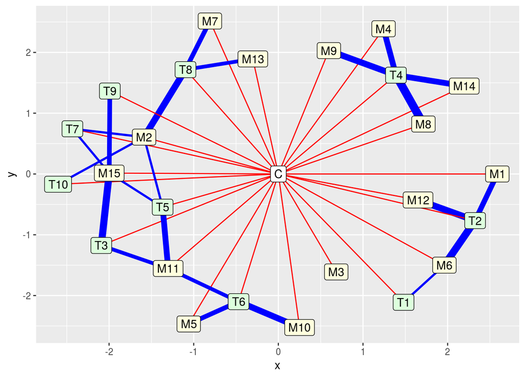

```r
ig <- ig_from_house(houses)

# look at a few layouts
set.seed(0)
l1 <- ig_layout(ig, igraph::layout_nicely, rescale=FALSE)
igl_plot(l1, ig)
```

```r
set.seed(0)
l2 <- ig_layout(ig, igraph::layout_nicely, rescale=TRUE)
```

```
## [1] "name"     "distance"
```

```
##   to from     weight    from_x       from_y to_x to_y color width
## 1  C  M15 0.10277012 -9.730198   0.07069816    0    0   red   0.5
## 2  C   M3        Inf  0.000000   0.00000000    0    0   red   0.5
## 3  C  M14 0.24824862  3.364477   2.21514067    0    0   red   0.5
## 4  C  M11 0.15262839 -4.207256  -5.02253725    0    0   red   0.5
## 5  C  M13 0.04463252 -3.524630  22.12621484    0    0   red   0.5
## 6  C   M5 0.05022714 -7.851468 -18.29603263    0    0   red   0.5
```

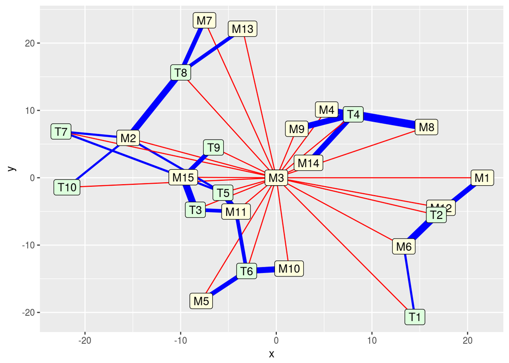

```r
igl_plot(l2, ig)
```

```
##   to from     weight      from_x    from_y to_x to_y color width
## 1  C  M15 0.10277012 -353.001598 -174.7011    0    0   red   0.5
## 2  C   M3        Inf  -28.492659  199.3510    0    0   red   0.5
## 3  C  M14 0.24824862   -4.978728 -310.1443    0    0   red   0.5
## 4  C  M11 0.15262839   61.366031  129.8504    0    0   red   0.5
## 5  C  M13 0.04463252 -212.074358  207.7776    0    0   red   0.5
## 6  C   M5 0.05022714  220.148446  235.3624    0    0   red   0.5
```

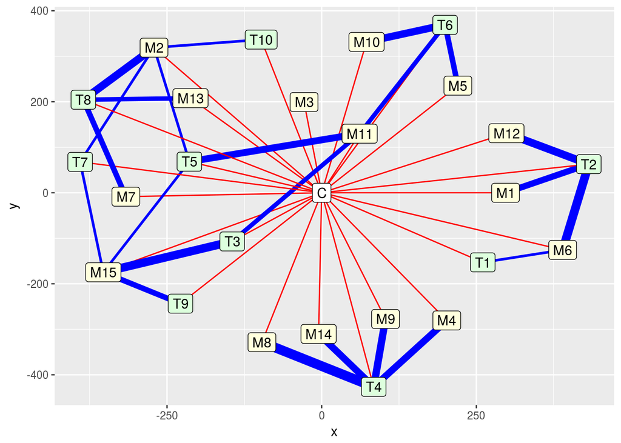

```r
set.seed(0)
l3 <- ig_layout(ig, igraph::layout_with_gem, rescale=FALSE)
igl_plot(l3, ig)
```

```r
set.seed(0)
l4 <- ig_layout(ig, igraph::layout_with_gem, rescale=TRUE)
```

```
## [1] "name"     "distance"
```

```
##   to from     weight       from_x    from_y to_x to_y color width
## 1  C  M15 0.10277012  -8.72089509 -4.315986    0    0   red   0.5
## 2  C   M3        Inf   0.00000000  0.000000    0    0   red   0.5
## 3  C  M14 0.24824862  -0.06465645 -4.027701    0    0   red   0.5
## 4  C  M11 0.15262839   2.79946790  5.923670    0    0   red   0.5
## 5  C  M13 0.04463252 -16.00415797 15.679902    0    0   red   0.5
## 6  C   M5 0.05022714  13.60039070 14.540280    0    0   red   0.5
```

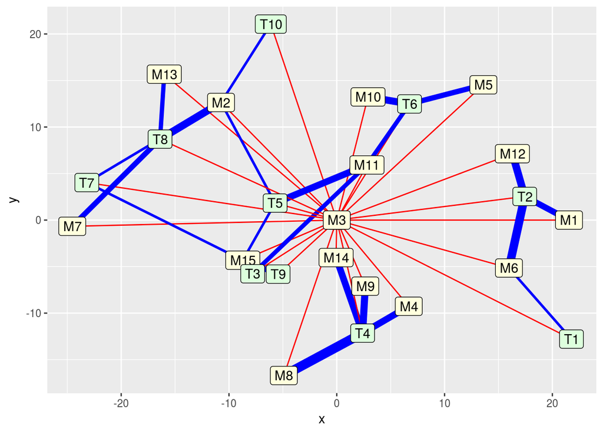

```r
igl_plot(l4, ig)
```